# Alphabetic only texts/strings

For the core parts of the Hybrid Cryptography project you are expected to work with text strings that only contain alphabetic characters, i.e. no spaces, no numbers, no punctuation, just the letters of the alphabet.

You will therefore need to write a function that extracts precisely the alphabetic content of a string. Let's suppose that you have done this and that you have defined the following function

```
def extract_text(text):
    # Body of the function which takes the string
    # text and returns a string containing only the
    # alphabetic content of text. For you to define...
```

Now as an example we will define the string `first_part` to be the string containing the first 4000 characters of the string `austen_text` whose content is the book *Pride and Prejudice* by Jane Austen. (4000 characters chosen so that we have started the actual book or, at least, the preface!) To do this we simply repeat the work done at the beginning of the notebook `get_online_texts.ipynb` where we noted that we could find the *utf-8* encoded version of *Pride and Prejudice* by Jane Austen here:

```
https://www.gutenberg.org/files/1342/1342-0.txt
```

and where we downloaded this as a string using the function `url_to_text_utf8` defined below.

```python
import requests, os
```

```python
def url_to_text_utf8(url):
    '''
    Given a url for a text that is
    'utf-8' encoded this function
    returns that text.
    '''
    response = requests.get(url)
    response.encoding = 'utf-8-sig'
    return response.text
```

So now let's get the book *Pride and Prejudice* (as a string) once again.

```python
austen_text = url_to_text_utf8("https://www.gutenberg.org/files/1342/1342-0.txt")
```

And continue by defining `first_part`.

```python
first_part = austen_text[:4000]
```

Now let's have a look at this string. Notice all the space and other junk...

```python
first_part
```

```
'The Project Gutenberg eBook of Pride and prejudice, by Jane Austen\r\n\r\nThis eBook is for the use of anyone anywhere in the United States and\r\nmost other parts of the world at no cost and with almost no restrictions\r\nwhatsoever. You may copy it, give it away or re-use it under the terms\r\nof…
```

### Extract the alphabetic content of the string `first_part`

To extract the alphabetic content (i.e. alphabetic characters) from the string `first_part` we pass it to the function `extract_text`. Using the following line of code we assign the variable `alphabetic_first_part` to the resulting string.

```
alphabetic_first_part = extract_text(first_part)
```

And now, when we inspect the string returned by `extract_text` by, for example, running a cell containing only the line...

```
alphabetic_first_part
```

we see $-$ provided `extract_text` is correctly defined $-$ that this string is as follows:

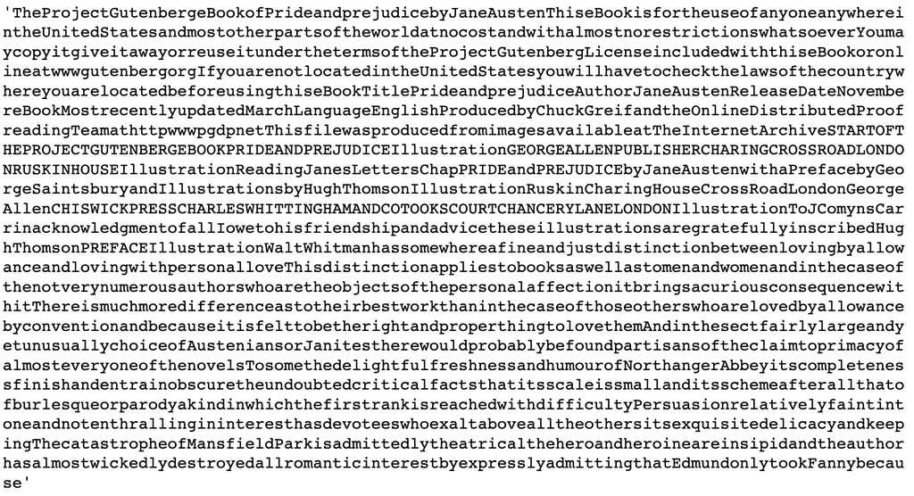

## The Point

You can convert all of the string `austen_text` in this way to obtain a purely alphabetic string then use it for encryption and decryption etc. (and/or save it in a file for use later on). You can (and should) of course follow the same process for any of the text (.txt) files on the Hybrid Cryptography GitHub page, or for any other text files that you choose to use.

## Note on cases

You can design your encryption and decryption functions so that they preserve case. However you can also decide to work only in upper case or lower case (although preservation of case would be a nice feature to have). To do this you would simply have to convert your string to lower or upper case.

For example executing the line

```
alphabetic_first_part.lower()
```

returns the string:

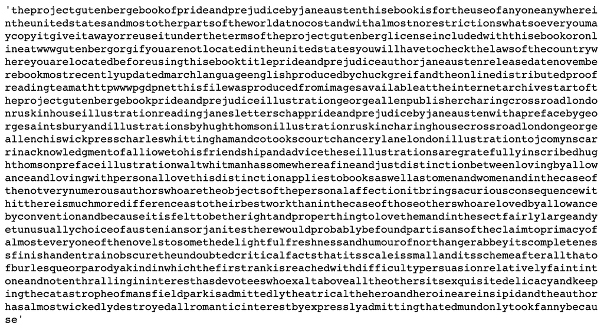

whereas executing the line

```
alphabetic_first_part.upper()
```

returns the string

[figure not shown]